# Funktionelle Genomanalysen 2023 (09-CRT-A006)

Tutorial: Colokalisierung & Mendelische Randomisierung

Dr. Janne Pott

09.-11. Juni 2023

## Allgemeine Informationen

**Ziel**: Das Ziel dieses Tutoriums ist es, fuer zwei Phaenotypen eine Colokalisationsanalyse und eine Mendelische Randomisierung durchzufuehren, um die praktische Anwendung und Interpretation der Ergebnisse aufzufuehren.

**Daten**: Wir werden in diesem Beispiel Teilmengen von bereits publizierten GWAS verwenden

- LDLC Summary Statistics von [Surakka, I. et al. The impact of low-frequency and rare variants on lipid levels. Nat. Genet. 47, 589–597 (2015).](https://www.nature.com/articles/ng.3300), Link to data: http://diagram-consortium.org/2015_ENGAGE_1KG/
- CAD Summary Statistics von [Nikpay, M. et al. A comprehensive 1,000 Genomes-based genome-wide association meta-analysis of coronary artery disease. Nat. Genet. 47, 1121–1130 (2015).](https://www.nature.com/articles/ng.3396), Link to data: http://www.cardiogramplusc4d.org/data-downloads/
- Sitosterol Summary Statistics von [Scholz, M. et al. Genome-wide meta-analysis of phytosterols reveals five novel loci and a detrimental effect on coronary atherosclerosis. Nat Commun 13, 143 (2022).](https://www.nature.com/articles/s41467-021-27706-6), Link to data: https://zenodo.org/record/5607613

Diese Beispieldaten wurden gewaehlt, weil sie auch in der Vorlesung vorkommen. Allerdings wird hier nur ein Lokus betrachtet:

## Coloc

In diesem Abschnitt werden wir drei Colocalisierungen in R durchfuehren

Weitere Inforamtionen zum *coloc* R-Paket finden Sie unter https://chr1swallace.github.io/coloc/.

### Initialisierung

Zuerst laden wir alle notwendigen Pakete.

```r
# load required packages
library(coloc)
```

```r
library(data.table)
setDTthreads(1)
library(ggplot2)
library(ggpubr)
library(hyprcoloc)
library(plyr)
```

### Daten einlesen

Im Moodle-Kurs finden Sie eine .RData Datei, die bereits alle notwendigen Tabellen enthaelt und einfach in R eingelesen werden kann. Sie enthaelt die folgenden *data.tables*:

- tab_LDL
- tab_CAD
- tab_SIT

Das R-Paket *data.table* ist sehr performant fuer das handling von grossen Daten in R. Weitere Infos dazu finden Sie unter https://r-datatable.com.

```r
load("RPractical.RData")
ls()
```

```
## [1] "tab_CAD" "tab_LDL" "tab_SIT"
```

```r
str(tab_LDL)
```

```
## Classes 'data.table' and 'data.frame':   7404 obs. of  8 variables:
##  $ chr     : chr  "chr2" "chr2" "chr2" "chr2" ...
##  $ pos     : int  43072828 43072997 43073247 43073548 43074225 43074392 43074468 43075563 43076226 43076271 ...
##  $ EA_LDL  : chr  "G" "G" "G" "G" ...
##  $ OA_LDL  : chr  "C" "T" "A" "T" ...
##  $ beta_LDL: num  -0.002394 0.000829 -0.00232 -0.002323 -0.004573 ...
##  $ SE_LDL  : num  0.00634 0.0071 0.00634 0.00633 0.00646 ...
##  $ pval_LDL: num  0.706 0.907 0.714 0.714 0.479 ...
##  $ N_LDL   : int  58309 58313 58314 58310 58322 58312 58312 58311 53241 58316 ...
##  - attr(*, ".internal.selfref")=<externalptr>
```

```r
str(tab_CAD)
```

```
## Classes 'data.table' and 'data.frame':   7558 obs. of  10 variables:
##  $ rsID    : chr  "rs1123695" "rs78735937" "rs57242328" "rs4953671" ...
##  $ chr     : int  2 2 2 2 2 2 2 2 2 2 ...
##  $ pos     : int  43072828 43072997 43073247 43073548 43074225 43074392 43074468 43075563 43076226 43076271 ...
##  $ EA_CAD  : chr  "G" "G" "G" "G" ...
##  $ OA_CAD  : chr  "C" "T" "A" "T" ...
##  $ EAF_CAD : num  0.635 0.762 0.635 0.635 0.635 ...
##  $ beta_CAD: num  0.0192 -0.0191 0.019 0.0192 0.0187 ...
##  $ SE_CAD  : num  0.00957 0.01094 0.00956 0.00955 0.00953 ...
##  $ pval_CAD: num  0.0444 0.0808 0.0469 0.0444 0.0491 ...
##  $ N_CAD   : num  169427 169427 169427 169427 169427 ...
##  - attr(*, ".internal.selfref")=<externalptr>
```

```r
str(tab_SIT)
```

```
## Classes 'data.table' and 'data.frame':   6176 obs. of  10 variables:
##  $ rsID    : chr  "rs1123695" "rs78735937" "rs57242328" "rs4953671" ...
##  $ chr     : int  2 2 2 2 2 2 2 2 2 2 ...
##  $ pos     : num  43072828 43072997 43073247 43073548 43074225 ...
##  $ EA_SIT  : chr  "C" "T" "A" "T" ...
##  $ OA_SIT  : chr  "G" "G" "G" "G" ...
##  $ EAF_SIT : num  0.334 0.234 0.334 0.334 0.334 ...
##  $ beta_SIT: num  -0.000746 0.008861 -0.000669 -0.000584 -0.000699 ...
##  $ SE_SIT  : num  0.00718 0.00799 0.00718 0.00717 0.00717 ...
##  $ pval_SIT: num  0.908 0.264 0.917 0.926 0.913 ...
##  $ N_SIT   : int  9755 9755 9755 9755 9755 9755 9755 9755 9755 9755 ...
##  - attr(*, ".internal.selfref")=<externalptr>
```

```r
tab_SIT[pval_SIT == min(pval_SIT),]
```

```
##         rsID chr      pos EA_SIT OA_SIT   EAF_SIT  beta_SIT     SE_SIT
## 1: rs4299376   2 44072576      T      G 0.6822883 -0.185747 0.00708307
##        pval_SIT N_SIT
## 1: 1.48146e-151  9755
```

Die Datensaetze sind jeweils schon eingeschraenkt auf Chromosom 2 und die Region um best-assoziierten SNP von SIT herum (Basenposition 44072576 +/- 1 Mio. Basen).

### Plots

Es ist immer gut, die Daten auch zu visualisieren. Deswegen werden wir zunaechst drei Plots erzeugen, um die lokale Assoziation per Phaenotyp zu sehen.

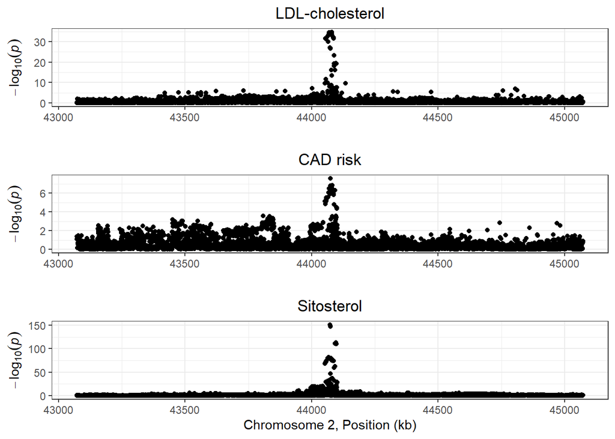

```r
p1 <- ggplot(tab_LDL, aes(x = pos, y = -log10(pval_LDL))) +
  geom_point() +
  labs(x = "", y = bquote(-log[10](italic(p))),
       title = "LDL-cholesterol") +
  theme_bw() +
  theme(plot.title = element_text(hjust = 0.5)) +
  scale_x_continuous(breaks = c(43000000, 43500000, 44000000, 44500000, 45000000),
                     labels = c(43000, 43500, 44000, 44500, 45000))

p2 <- ggplot(tab_CAD, aes(x = pos, y = -log10(pval_CAD))) +
  geom_point() +
  labs(x = "", y = bquote(-log[10](italic(p))),
         title = "CAD risk") +
  theme_bw() +
  theme(plot.title = element_text(hjust = 0.5)) +
  scale_x_continuous(breaks = c(43000000, 43500000, 44000000, 44500000, 45000000),
                     labels = c(43000, 43500, 44000, 44500, 45000))

p3 <- ggplot(tab_SIT, aes(x = pos, y = -log10(pval_SIT))) +
  geom_point() +
  labs(x = "", y = bquote(-log[10](italic(p))),
         title = "Sitosterol") +
  theme_bw() +
  theme(plot.title = element_text(hjust = 0.5)) +
  scale_x_continuous(name = paste0("Chromosome 2, Position (kb)"),
                     breaks = c(43000000, 43500000, 44000000, 44500000, 45000000),
                     labels = c(43000, 43500, 44000, 44500, 45000))

ggpubr::ggarrange(p1, p2,p3,
 heights = c(1, 1), nrow = 3,
 ncol = 1, align = "hv")
```

Es gibt also fuer alle drei Phaenotypen ein Signal, aber wir koennen die Region auch verkleinern, da die Assoziationen am Rand alle nicht genomweit signifkant sind.

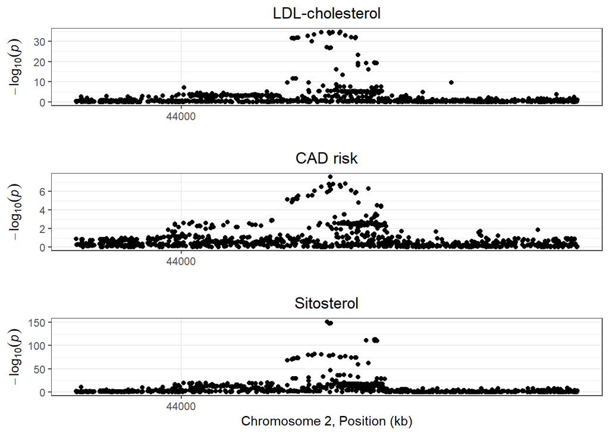

```r
tab_LDL = tab_LDL[pos > 44072576 - 125000 & pos < 44072576 + 125000,]
tab_CAD = tab_CAD[pos > 44072576 - 125000 & pos < 44072576 + 125000,]
tab_SIT = tab_SIT[pos > 44072576 - 125000 & pos < 44072576 + 125000,]

p1 <- ggplot(tab_LDL, aes(x = pos, y = -log10(pval_LDL))) +
  geom_point() +
  labs(x = "", y = bquote(-log[10](italic(p))),
       title = "LDL-cholesterol") +
  theme_bw() +
  theme(plot.title = element_text(hjust = 0.5)) +
  scale_x_continuous(breaks = c(43000000, 43500000, 44000000, 44500000, 45000000),
                     labels = c(43000, 43500, 44000, 44500, 45000))

p2 <- ggplot(tab_CAD, aes(x = pos, y = -log10(pval_CAD))) +
  geom_point() +
  labs(x = "", y = bquote(-log[10](italic(p))),
         title = "CAD risk") +
  theme_bw() +
  theme(plot.title = element_text(hjust = 0.5)) +
  scale_x_continuous(breaks = c(43000000, 43500000, 44000000, 44500000, 45000000),
                     labels = c(43000, 43500, 44000, 44500, 45000))

p3 <- ggplot(tab_SIT, aes(x = pos, y = -log10(pval_SIT))) +
  geom_point() +
  labs(x = "", y = bquote(-log[10](italic(p))),
         title = "Sitosterol") +
  theme_bw() +
  theme(plot.title = element_text(hjust = 0.5)) +
  scale_x_continuous(name = paste0("Chromosome 2, Position (kb)"),
                     breaks = c(43000000, 43500000, 44000000, 44500000, 45000000),
                     labels = c(43000, 43500, 44000, 44500, 45000))

ggpubr::ggarrange(p1, p2,p3,
 heights = c(1, 1), nrow = 3,
 ncol = 1, align = "hv")
```

### Harmonisierung

Der Vergleich kann nur mit SNPs durchgefuerht werden, die fuer beide bzw alle drei Phaenotypen vorhanden sind. Daher werden nun die drei Tabellen zusammengefuegt.

```r
tab_LDL[,chr := 2]
tab_dummy = data.frame(pos = unique(c(tab_CAD$pos, tab_LDL$pos, tab_SIT$pos)))

tab = Reduce(function(x, y) plyr::join(x, y), list(tab_dummy, tab_CAD, tab_LDL, tab_SIT))
tab = tab[complete.cases(tab),]
```

Die Richtung des Effekts ist fuer die Colokalisierung nicht relevant. Daher muss nicht zwingend auf das gleiche Effektallel gedreht werden. Aber es ist sehr ratsam zumindest zu pruefen, dass die gleichen zwei Allele getestet wurden. In diesem Tutorial werden ich die Allele jetzt angleichen.

```r
setDT(tab)
tab[,table(EA_SIT == EA_LDL, OA_SIT == EA_LDL)]
```

```
##
##         FALSE TRUE
##   FALSE     0  885
##   TRUE      1    0
```

```r
tab[,table(EA_SIT == EA_CAD, OA_SIT == EA_CAD)]
```

```
##
##         FALSE TRUE
##   FALSE     1  732
##   TRUE    153    0
```

```r
tab = tab[EA_SIT == EA_CAD | OA_SIT == EA_CAD,]
tab[,table(EA_SIT == EA_CAD, OA_SIT == EA_CAD)]
```

```
##
##         FALSE TRUE
##   FALSE     0  732
##   TRUE    153    0
```

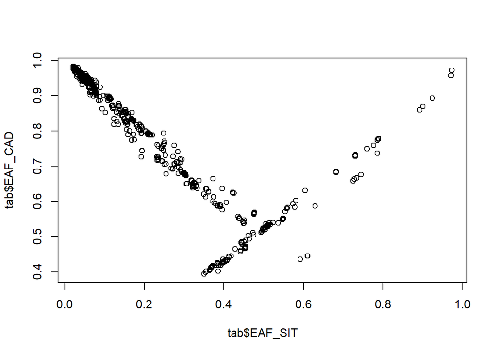

```r
plot(tab$EAF_SIT, tab$EAF_CAD)
```

[figure not shown]

```r
tab[OA_SIT == EA_LDL, beta_LDL := beta_LDL * (-1)]
tab[OA_SIT == EA_CAD, beta_CAD := beta_CAD * (-1)]
tab[OA_SIT == EA_CAD, EAF_CAD := 1 - EAF_CAD]
```

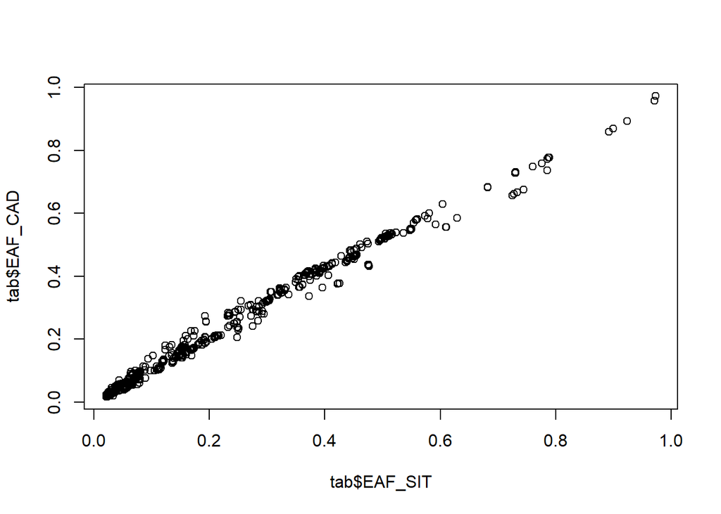

```r
plot(tab$EAF_SIT, tab$EAF_CAD)
```

```r
tab[,EA_CAD := NULL]
tab[,OA_CAD := NULL]
tab[,EA_LDL := NULL]
tab[,OA_LDL := NULL]

tab[,MAF_CAD := ifelse(EAF_CAD < 0.5, EAF_CAD, 1 - EAF_CAD)]
tab[,MAF_SIT := ifelse(EAF_SIT < 0.5, EAF_SIT, 1 - EAF_SIT)]
tab[,MAF_LDL := MAF_SIT]
```

**Hinweis**: Fuer die LDL Daten waren in den Summary Statistics keine EAF Information gegeben. Daher habe ich mich hier entschieden, die gleichen Frequenzen wie bei Sitosterol anzunehmen. Alternativ haette man auch die Frequenzen aus dem Referenzgenom verwenden koennen.

Nach diesen Harmonisierungsschritten kann man nun die Listen erzeugen, die als Input fuer die *coloc* Funktion benoetigt werden.

### Coloc

```r
D1 <- list(
 type = "quant", # quantitative trait
 beta = tab$beta_LDL,
 varbeta = tab$SE_LDL^2, # note that this is standard error squared
 pvalues = tab$pval_LDL,
 N = tab$N_LDL,
 MAF = tab$MAF_LDL,
 snp = tab$rsID,
 sdY = 1 # external information
)

D2 <- list(
 type = "cc", # case-control trait
 beta = tab$beta_CAD,
 varbeta = tab$SE_CAD^2,
 pvalues = tab$pval_CAD,
 N = 43159+126268, # external information
 s = 43159/(43159+126268), # external information
 MAF = tab$MAF_CAD,
 snp = tab$rsID
)

D3 <- list(
 type = "quant", # quantitative trait
 beta = tab$beta_SIT,
 varbeta = tab$SE_SIT^2,
 pvalues = tab$pval_SIT,
 N = tab$N_SIT,
 MAF = tab$MAF_SIT,
 snp = tab$rsID,
 sdY = 1 # external information
)
```

Jetzt koennen wir endlich paarweise testen.

**Hinweis**: Coloc ist eine Bayesianische Inferenzmethode und benoetigt prior probabilities:

- p1: prior probability dass ein SNP mit dem ersten Phaenotyp assoziiert ist (default 1e-4)
- p2: prior probability dass ein SNP mit dem zweiten Phaenotyp assoziiert ist (default 1e-4)
- p12: prior probability dass ein SNP mit beiden Phaenotypen assoziiert ist (default 1e-5)

```r
coloc_res1 = coloc.abf(D1, D2, p1 = 1e-4, p2 = 1e-4, p12 = 1e-5)
```

```
## PP.H0.abf PP.H1.abf PP.H2.abf PP.H3.abf PP.H4.abf
##  3.05e-33  1.68e-04  1.85e-31  9.18e-03  9.91e-01
## [1] "PP abf for shared variant: 99.1%"
```

```r
coloc_res2 = coloc.abf(D1, D3, p1 = 1e-4, p2 = 1e-4, p12 = 1e-5)
```

```
## PP.H0.abf PP.H1.abf PP.H2.abf PP.H3.abf PP.H4.abf
## 3.84e-173 2.12e-144  1.81e-29  1.00e+00  6.79e-06
## [1] "PP abf for shared variant: 0.000679%"
```

```r
coloc_res3 = coloc.abf(D2, D3, p1 = 1e-4, p2 = 1e-4, p12 = 1e-5)
```

```
## PP.H0.abf PP.H1.abf PP.H2.abf PP.H3.abf PP.H4.abf
## 2.94e-147 1.78e-145  1.39e-03  8.30e-02  9.16e-01
## [1] "PP abf for shared variant: 91.6%"
```

Zusammenfassung: in der paarweisen Analyse teilen sich LDL und CAD, und SIT und CAD ein kausales Signal, aber beim Vergleich SIT zu LDL ist die posterior probability fuer unterschiedliche kausale Signale am staerksten.

Was passiert, wenn wir alle drei Phaenotypen gleichzeitig analysieren?

```r
betas = as.matrix(tab[,c(9,16,5),with=F])
ses = as.matrix(tab[,c(10,17,6),with=F])

hyprcoloc_results <- hyprcoloc(betas, ses,
                               trait.names = c("LDL", "SIT","CAD"),
                               snp.id = tab$rsID,
                               binary.outcomes = c(0, 0,1),
                               prior.1 = 1e-04, prior.c = 0.02)
hyprcoloc_results$results
```

```
##   iteration   traits posterior_prob regional_prob candidate_snp
## 1         1 LDL, CAD         0.9765        0.9992    rs76866386
##   posterior_explained_by_snp dropped_trait
## 1                     0.2826            NA
```

```r
tab[rsID == "rs76866386",]
```

```
##         pos       rsID chr  EAF_CAD beta_CAD    SE_CAD pval_CAD  N_CAD
## 1: 44075483 rs76866386   2 0.058038 -0.10896 0.0207805 1.58e-07 169427
##     beta_LDL   SE_LDL pval_LDL N_LDL EA_SIT OA_SIT    EAF_SIT  beta_SIT
## 1: -0.146824 0.011847 3.12e-35 58304      C      T 0.06340521 -0.252501
##       SE_SIT    pval_SIT N_SIT  MAF_CAD    MAF_SIT    MAF_LDL
## 1: 0.0133023 2.73675e-80  9755 0.058038 0.06340521 0.06340521
```

Mittels HyperColoc koennen wir sagen, dass LDL und CAD mit 97% posterior probability sich ein kausale Signal teilen, rs76866386, aber nicht mit SIT.

Woran kann das liegen? Im Plot haben wir anfangs gesehen, dass das Signal nicht gleich ausschaut: bei SIT gibt es zwei Mini-Cluster mit extrem niedrigen p-Werten, einmal um $1x10^-150$ herum und eines um die $1x10^-110$ herum. Was passiert wenn wir diese SNPs weglassen? Diese stellen womoeglich ein Sitosterol-spezifisches Signal dar (mehrere unabhaengige Hits ab gleichen Lokus)

### Sensitivitaet

```r
tab2 = copy(tab)
tab2 = tab2[pval_SIT >= 1e-100,]
D1 <- list(
 type = "quant", # quantitative trait
 beta = tab2$beta_LDL,
 varbeta = tab2$SE_LDL^2, # note that this is standard error squared
 pvalues = tab2$pval_LDL,
 N = tab2$N_LDL,
 MAF = tab2$MAF_LDL,
 snp = tab2$rsID,
 sdY = 1 # external information
)

D2 <- list(
 type = "cc", # case-control trait
 beta = tab2$beta_CAD,
 varbeta = tab2$SE_CAD^2,
 pvalues = tab2$pval_CAD,
 N = 43159+126268, # external information
 s = 43159/(43159+126268), # external information
 MAF = tab2$MAF_CAD,
 snp = tab2$rsID
)

D3 <- list(
 type = "quant", # quantitative trait
 beta = tab2$beta_SIT,
 varbeta = tab2$SE_SIT^2,
 pvalues = tab2$pval_SIT,
 N = tab2$N_SIT,
 MAF = tab2$MAF_SIT,
 snp = tab2$rsID,
 sdY = 1 # external information
)

coloc_res4 = coloc.abf(D1, D2, p1 = 1e-4, p2 = 1e-4, p12 = 1e-5)
```

```
## PP.H0.abf PP.H1.abf PP.H2.abf PP.H3.abf PP.H4.abf
##  3.05e-33  1.68e-04  1.76e-31  8.71e-03  9.91e-01
## [1] "PP abf for shared variant: 99.1%"
```

```r
coloc_res5 = coloc.abf(D1, D3, p1 = 1e-4, p2 = 1e-4, p12 = 1e-5)
```

```
## PP.H0.abf PP.H1.abf PP.H2.abf PP.H3.abf PP.H4.abf
## 6.62e-106  3.65e-77  6.62e-31  3.55e-02  9.64e-01
## [1] "PP abf for shared variant: 96.4%"
```

```r
coloc_res6 = coloc.abf(D2, D3, p1 = 1e-4, p2 = 1e-4, p12 = 1e-5)
```

```
## PP.H0.abf PP.H1.abf PP.H2.abf PP.H3.abf PP.H4.abf
##  5.27e-79  3.04e-77  5.27e-04  2.94e-02  9.70e-01
## [1] "PP abf for shared variant: 97%"
```

```r
betas = as.matrix(tab2[,c(9,16,5),with=F])
ses = as.matrix(tab2[,c(10,17,6),with=F])

hyprcoloc_results2 <- hyprcoloc(betas, ses,
                               trait.names = c("LDL", "SIT","CAD"),
                               snp.id = tab$rsID,
                               binary.outcomes = c(0, 0,1),
                               prior.1 = 1e-04, prior.c = 0.02)
hyprcoloc_results2$results
```

```
##   iteration        traits posterior_prob regional_prob candidate_snp
## 1         1 LDL, SIT, CAD         0.7718        0.9991    rs75331444
##   posterior_explained_by_snp dropped_trait
## 1                     0.5879            NA
```

```r
tab2[rsID == "rs75331444",]
```

```
##         pos       rsID chr  EAF_CAD  beta_CAD    SE_CAD pval_CAD  N_CAD
## 1: 44069772 rs75331444   2 0.057324 -0.106924 0.0209206 3.21e-07 169427
##     beta_LDL SE_LDL pval_LDL N_LDL EA_SIT OA_SIT   EAF_SIT  beta_SIT    SE_SIT
## 1: -0.147637 0.0119 2.63e-35 58305      A      G 0.0637627 -0.254072 0.0132927
##       pval_SIT N_SIT  MAF_CAD   MAF_SIT   MAF_LDL
## 1: 2.17319e-81  9755 0.057324 0.0637627 0.0637627
```

Jetzt teilen sich alle drei Phaenotypen ein kausales Signal.

Man kann also sagen, dass es an diesem Lokus ein Signal fuer SIT, LDL, und CAD gibt, aber das es bei SIT zusaetzlich noch weitere Signale gibt.